# Análisis de Habilidades Blandas en Postgrados (Sección Venezuela)

Juan C. Correa

2024-06-07

# Carga de datos

Primero, se carga el paquete “readtext” y se lee el directorio “Venezuela” para extraer los textos de los documentos PDF. Luego, se elimina la extensión “.pdf” del identificador de cada documento.

```r
library(readtext)
textos <- readtext("Venezuela")
textos$doc_id <- gsub("\\.pdf$|\\.docx$", "", textos$doc_id)
```

Luego, pasamos a relacionar cada programa de postgrado con su correspondiente nivel educativo para observar cuántos programas hay de cada nivel:

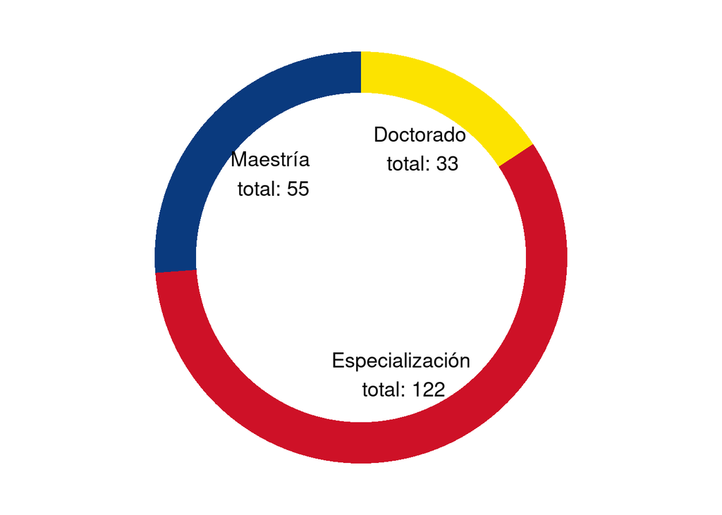

```r
library(dplyr)
textos <- mutate(textos,
                 Program = ifelse(
                   grepl("Doctorado en", text), "Doctorado",
                        ifelse(grepl("Maestría", text), "Maestría",
                               "Especialización")))
Programas <- data.frame(table(textos$Program))
colnames(Programas)[1] <- "Programa"
colnames(Programas)[2] <- "Total"

library(ggplot2)
Programas$fraction = Programas$Total / sum(Programas$Total)
Programas$ymax = cumsum(Programas$fraction)
Programas$ymin = c(0, head(Programas$ymax, n=-1))
Programas$ymax <- cumsum(Programas$fraction)
Programas$ymin <- c(0, head(Programas$ymax, n=-1))
Programas$labelPosition <- (Programas$ymax + Programas$ymin) / 2
Programas$label <- paste0(Programas$Programa, "\n total: ", Programas$Total)
ggplot(Programas, aes(ymax=ymax, ymin=ymin, xmax=4, xmin=3, fill=Programa)) +
  geom_rect() +
  geom_text(x=2, aes(y=labelPosition, label=label, color=Programa), size=5) +
  scale_fill_manual(values=c("Doctorado"="#FCE300", "Maestría"="#0A3A7E", "Especialización"="#CE1127")) +
  scale_color_manual(values=c("Doctorado"="black", "Maestría"="black", "Especialización"="black")) + # Custom text colors
  coord_polar(theta="y") +
  xlim(c(-1, 4)) +
  theme_void() +
  theme(legend.position = "none")
```

Ahora, pasamos a crear el corpus lingüístico. Para ello, cada documento se va a descomponer en número de palabras totales (tokens), número de palabras únicas (types) y número de oraciones (sentences). Esto nos permitirá observar la longitud de cada oferta de postgrado.

```r
library(quanteda)
Textos <- corpus(textos$text)
docvars(Textos, "Program") <- textos$Program
head(summary(Textos), 10)
```

```
##      Text Types Tokens Sentences         Program
## 1   text1   213    484        12       Doctorado
## 2   text2   240    703        11 Especialización
## 3   text3   172    365        10 Especialización
## 4   text4   170    335         9 Especialización
## 5   text5   166    337         8       Doctorado
## 6   text6   214    578         8        Maestría
## 7   text7   248    539        14        Maestría
## 8   text8   184    408         7        Maestría
## 9   text9   220    499        12        Maestría
## 10 text10   218    424        10        Maestría
```

```r
Programs <- tokens(Textos,
                     remove_numbers = TRUE,
                     remove_punct = TRUE,
                     remove_url = TRUE,
                     remove_symbols = TRUE) %>%
  tokens_remove(stopwords("spanish"))
```

Ahora, pasamos a hacer a buscar con el filtro contextual así:

```r
s1 <- data.frame(kwic(Programs, pattern = phrase("pensamiento crítico")))
s2 <- data.frame(kwic(Programs, pattern = phrase("solucionar problemas")))
s3 <- data.frame(kwic(Programs, pattern = "comunicar"))
s4 <- data.frame(kwic(Programs, pattern = "creatividad"))
s5 <- data.frame(kwic(Programs, pattern = "paciencia"))
s6 <- data.frame(kwic(Programs, pattern = "crear"))
s7 <- data.frame(kwic(Programs, pattern = "liderar"))
s8 <- data.frame(kwic(Programs, pattern = "resolver"))
s9 <- data.frame(kwic(Programs, pattern = "comprometer"))
s10 <- data.frame(kwic(Programs, pattern = "comprometerse"))
s11 <- data.frame(kwic(Programs, pattern = "gestionar"))
s12 <- data.frame(kwic(Programs, pattern = "reflexionar"))
s13 <- data.frame(kwic(Programs, pattern = "controlar"))
s14 <- data.frame(kwic(Programs, pattern = "ético"))
s15 <- data.frame(kwic(Programs, pattern = "tolerar"))
s16 <- data.frame(kwic(Programs, pattern = "argumentar"))
s17 <- data.frame(kwic(Programs, pattern = "conflictos"))
s18 <- data.frame(kwic(Programs, pattern = "negociar"))
s19 <- data.frame(kwic(Programs, pattern = "comprender"))
s20 <- data.frame(kwic(Programs, pattern = "equipos"))
s21 <- data.frame(kwic(Programs, pattern = "planificar"))
s22 <- data.frame(kwic(Programs, pattern = "generar"))
s23 <- data.frame(kwic(Programs, pattern = "empatía"))
s24 <- data.frame(kwic(Programs, pattern = "compartir"))
s25 <- data.frame(kwic(Programs, pattern = "analizar"))
s26 <- data.frame(kwic(Programs, pattern = "reconocer"))
s27 <- data.frame(kwic(Programs, pattern = "orientar"))
s28 <- data.frame(kwic(Programs, pattern = "respetar"))
s29 <- data.frame(kwic(Programs, pattern = "motivar"))
s30 <- data.frame(kwic(Programs, pattern = "cooperar"))
s31 <- data.frame(kwic(Programs, pattern = "fortalecer"))
s32 <- data.frame(kwic(Programs, pattern = "impulsar"))
s33 <- data.frame(kwic(Programs, pattern = "acercar"))
s34 <- data.frame(kwic(Programs, pattern = "ayudar"))
s35 <- data.frame(kwic(Programs, pattern = "cambiar"))
s36 <- data.frame(kwic(Programs, pattern = "apreciar"))
s37 <- data.frame(kwic(Programs, pattern = "dirigir"))
s38 <- data.frame(kwic(Programs, pattern = "fomentar"))
s39 <- data.frame(kwic(Programs, pattern = "interactuar"))
s40 <- data.frame(kwic(Programs, pattern = "identificar"))
s41 <- data.frame(kwic(Programs, pattern = "competir"))
s42 <- data.frame(kwic(Programs, pattern = "manifestar"))
s43 <- data.frame(kwic(Programs, pattern = "responsable"))
s44 <- data.frame(kwic(Programs, pattern = "evaluar"))
s45 <- data.frame(kwic(Programs, pattern = "innovar"))
s46 <- data.frame(kwic(Programs, pattern = "decidir"))
s47 <- data.frame(kwic(Programs, pattern = phrase("tomar decisiones")))
s48 <- data.frame(kwic(Programs, pattern = "flexibilidad"))
s49 <- data.frame(kwic(Programs, pattern = "persua*"))
s50 <- data.frame(kwic(Programs, pattern = "convencer"))

df_list <- mget(paste0("s", 1:50))
SS <- do.call(rbind, df_list)
SS$Skill <- rownames(SS)
SS$Skill <- gsub("\\..*", "", SS$Skill)
rm(list=setdiff(ls(), "SS"))
variable.names(SS)
```

```
## [1] "docname" "from"    "to"      "pre"     "keyword" "post"    "pattern"
## [8] "Skill"
```

```r
head(SS, 5)
```

```
##      docname from   to
## s1.1  text21   56   57
## s1.2 text158 2797 2798
## s1.3 text158 4260 4261
## s1.4 text158 7202 7203
## s1.5 text159 2805 2806
##                                                             pre
## s1.1 intercambio interdisciplinar plural enriquecer profundizar
## s1.2              carácter público calidad innovación ejercicio
## s1.3                Aragua Libertad Universidad promoverá valor
## s1.4   estrategia abarca profundización ampliación conocimiento
## s1.5              carácter público calidad innovación ejercicio
##                  keyword
## s1.1 pensamiento crítico
## s1.2 pensamiento crítico
## s1.3 pensamiento crítico
## s1.4 pensamiento crítico
## s1.5 pensamiento crítico
##                                                             post
## s1.1 creativo dirigido profesionales preocupados acontecimientos
## s1.2          reflexivo inclusión pertinencia formación integral
## s1.3                estudiantes puedan emitir juicios personales
## s1.4         creativo analítico Modelo Educativo Especialización
## s1.5          reflexivo inclusión pertinencia formación integral
##                  pattern Skill
## s1.1 pensamiento crítico    s1
## s1.2 pensamiento crítico    s1
## s1.3 pensamiento crítico    s1
## s1.4 pensamiento crítico    s1
## s1.5 pensamiento crítico    s1
```

```r
Skills <- data.frame(SkillCode = c(paste0("s", 1:50)),
                     Skill = c("pensamiento crítico",
                              "solucionar problemas",
                              "comunicar",
                              "creatividad",
                              "paciencia",
                              "crear",
                              "liderar",
                              "resolver",
                              "comprometer",
                              "comprometerse",
                              "gestionar",
                              "reflexionar",
                              "controlar",
                              "ético",
                              "tolerar",
                              "argumentar",
                              "conflictos",
                              "negociar",
                              "comprender",
                              "equipos",
                              "planificar",
                              "generar",
                              "empatía",
                              "compartir",
                              "analizar",
                              "reconocer",
                              "orientar",
                              "respetar",
                              "motivar",
                              "cooperar",
                              "fortalecer",
                              "impulsar",
                              "acercar",
                              "ayudar",
                              "cambiar",
                              "apreciar",
                              "dirigir",
                              "fomentar",
                              "interactuar",
                              "identificar",
                              "competir",
                              "manifestar",
                              "responsable",
                              "evaluar",
                              "innovar",
                              "decidir",
                              "tomar decisiones",
                              "flexibilidad",
                              "persua*",
                              "convencer"))
```

# Paso 2: (Modelado de Red de Habilidades)

Ahora, pasamos a modelar las relaciones entre las habilidades y los programas de postgrado. Para ello, vamos a usar los datos de la tabla SS resultante del último código del paso anterior para construir la redd a través de una lista de aristas.

```r
network <- SS[c(1,8)]
head(network, 3)
```

```
##      docname Skill
## s1.1  text21    s1
## s1.2 text158    s1
## s1.3 text158    s1
```

Ahora, pasamos a graficar la red bipartita entre habilidades y programas

```r
library(igraph)
bn2 <- graph.data.frame(network,directed=FALSE)
bipartite.mapping(bn2)
```

```
## $res
## [1] TRUE
##
## $type
##  text21 text158 text159 text160 text161 text162 text163 text164 text165 text166
##   FALSE   FALSE   FALSE   FALSE   FALSE   FALSE   FALSE   FALSE   FALSE   FALSE
## text167 text168 text169 text170 text171 text172 text173 text174 text175 text176
##   FALSE   FALSE   FALSE   FALSE   FALSE   FALSE   FALSE   FALSE   FALSE   FALSE
## text177 text178 text179 text180 text181 text182 text183 text184 text185 text186
##   FALSE   FALSE   FALSE   FALSE   FALSE   FALSE   FALSE   FALSE   FALSE   FALSE
## text187 text188 text189 text116 text115  text13  text52 text139 text135   text7
##   FALSE   FALSE   FALSE   FALSE   FALSE   FALSE   FALSE   FALSE   FALSE   FALSE
##  text75  text76 text141 text143 text148  text24  text81  text83  text84 text122
##   FALSE   FALSE   FALSE   FALSE   FALSE   FALSE   FALSE   FALSE   FALSE   FALSE
## text144 text156 text157 text197 text202   text3   text9  text27 text105 text108
##   FALSE   FALSE   FALSE   FALSE   FALSE   FALSE   FALSE   FALSE   FALSE   FALSE
## text131 text142 text155  text80 text106 text154  text77 text191  text32  text36
##   FALSE   FALSE   FALSE   FALSE   FALSE   FALSE   FALSE   FALSE   FALSE   FALSE
##  text41  text64  text78 text125 text147 text192 text210  text29  text69  text73
##   FALSE   FALSE   FALSE   FALSE   FALSE   FALSE   FALSE   FALSE   FALSE   FALSE
## text102  text26 text145  text20 text100 text123 text152 text194   text1  text17
##   FALSE   FALSE   FALSE   FALSE   FALSE   FALSE   FALSE   FALSE   FALSE   FALSE
##  text23  text68  text97 text209  text18  text66  text85   text6  text19  text28
##   FALSE   FALSE   FALSE   FALSE   FALSE   FALSE   FALSE   FALSE   FALSE   FALSE
## text136 text207  text14 text199 text205 text206 text124 text126  text89  text90
##   FALSE   FALSE   FALSE   FALSE   FALSE   FALSE   FALSE   FALSE   FALSE   FALSE
## text198 text130 text153  text86 text112 text128 text140  text25 text104      s1
##   FALSE   FALSE   FALSE   FALSE   FALSE   FALSE   FALSE   FALSE   FALSE    TRUE
##      s2      s3      s4      s6      s7      s8     s10     s11     s12     s13
##    TRUE    TRUE    TRUE    TRUE    TRUE    TRUE    TRUE    TRUE    TRUE    TRUE
##     s14     s15     s17     s19     s20     s21     s22     s23     s24     s25
##    TRUE    TRUE    TRUE    TRUE    TRUE    TRUE    TRUE    TRUE    TRUE    TRUE
##     s26     s27     s28     s31     s32     s33     s34     s35     s36     s37
##    TRUE    TRUE    TRUE    TRUE    TRUE    TRUE    TRUE    TRUE    TRUE    TRUE
##     s38     s39     s40     s41     s43     s44     s45     s46     s47     s48
##    TRUE    TRUE    TRUE    TRUE    TRUE    TRUE    TRUE    TRUE    TRUE    TRUE
##     s49
##    TRUE
```

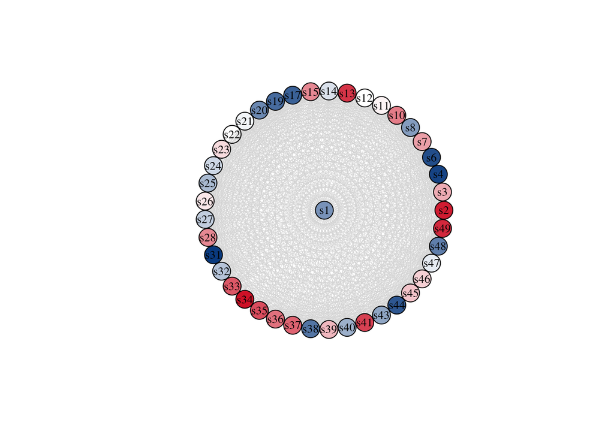

```r
V(bn2)$type <- bipartite_mapping(bn2)$type
V(bn2)$shape <- ifelse(V(bn2)$type, "circle", "square")
V(bn2)$label.cex <- ifelse(V(bn2)$type, 0.5, 1)
V(bn2)$size <- sqrt(igraph::degree(bn2))
E(bn2)$color <- "lightgrey"

bn2.pr <- bipartite.projection(bn2)
Terms <- bn2.pr$proj2

centrality_scores <- igraph::eigen_centrality(Terms)
centrality_scores <- centrality_scores$vector

color_palette <- colorRampPalette(c("#CE1127", "white", "#0A3A7E"))(length(unique(centrality_scores)))

# Assign colors to nodes based on their normalized centrality scores
node_colors <- color_palette[rank(centrality_scores)]

# Plot the network with node colors based on centrality
set.seed(915)


plot(Terms, vertex.label.color = "black", vertex.label.cex = 0.8, vertex.color = node_colors, vertex.size = 15, edge.width = 0.5, edge.color = "lightgray", layout = layout_as_star, main = "")
```

Seguimos con el cálculo de la importancia de cada habilidad y analicemos la correlación entre los cuatro indicadores de centralidad para ver si se comportan de una manera semejante a lo esperado por la evidencia empírica sobre indicadores de centralidad.

```r
BNA <- graph.data.frame(network, directed = FALSE)
Programs <- data.frame(Degree = igraph::degree(BNA),
                   Closeness = igraph::closeness(BNA),
                   Betweennes = igraph::betweenness(BNA),
                   Eigen = igraph::eigen_centrality(BNA))
Programs <- Programs[ -c(5:25) ]
rownames(Programs)
```

```
##   [1] "text21"  "text158" "text159" "text160" "text161" "text162" "text163"
##   [8] "text164" "text165" "text166" "text167" "text168" "text169" "text170"
##  [15] "text171" "text172" "text173" "text174" "text175" "text176" "text177"
##  [22] "text178" "text179" "text180" "text181" "text182" "text183" "text184"
##  [29] "text185" "text186" "text187" "text188" "text189" "text116" "text115"
##  [36] "text13"  "text52"  "text139" "text135" "text7"   "text75"  "text76"
##  [43] "text141" "text143" "text148" "text24"  "text81"  "text83"  "text84"
##  [50] "text122" "text144" "text156" "text157" "text197" "text202" "text3"
##  [57] "text9"   "text27"  "text105" "text108" "text131" "text142" "text155"
##  [64] "text80"  "text106" "text154" "text77"  "text191" "text32"  "text36"
##  [71] "text41"  "text64"  "text78"  "text125" "text147" "text192" "text210"
##  [78] "text29"  "text69"  "text73"  "text102" "text26"  "text145" "text20"
##  [85] "text100" "text123" "text152" "text194" "text1"   "text17"  "text23"
##  [92] "text68"  "text97"  "text209" "text18"  "text66"  "text85"  "text6"
##  [99] "text19"  "text28"  "text136" "text207" "text14"  "text199" "text205"
## [106] "text206" "text124" "text126" "text89"  "text90"  "text198" "text130"
## [113] "text153" "text86"  "text112" "text128" "text140" "text25"  "text104"
## [120] "s1"      "s2"      "s3"      "s4"      "s6"      "s7"      "s8"
## [127] "s10"     "s11"     "s12"     "s13"     "s14"     "s15"     "s17"
## [134] "s19"     "s20"     "s21"     "s22"     "s23"     "s24"     "s25"
## [141] "s26"     "s27"     "s28"     "s31"     "s32"     "s33"     "s34"
## [148] "s35"     "s36"     "s37"     "s38"     "s39"     "s40"     "s41"
## [155] "s43"     "s44"     "s45"     "s46"     "s47"     "s48"     "s49"
```

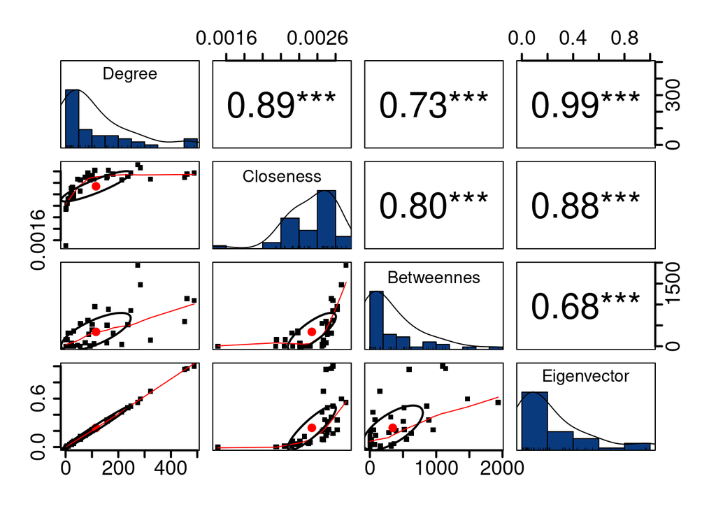

```r
Programs$SS <- rownames(Programs)
Programs <- Programs[order(Programs$SS), ]
Programs <- Programs[grepl("s", Programs$SS), ]
Programs <- Programs[1:4]
colnames(Programs)[4] <- "Eigenvector"

library(psych)

pairs.panels(Programs,
             method = "spearman",
             hist.col = "#0A3A7E",
             density = TRUE,
             ellipses = TRUE,
             pch = 15,
             cex = 1,
             cex.axis = 1.8,
             cex.labels = 1.5,
             lwd = 2,
             rug = TRUE,
             stars = TRUE)
```

Ahora, veamos el ranking de las diez habilidades más importantes

```r
IM <- as_incidence_matrix(BNA, names = TRUE, sparse = TRUE, types = bipartite_mapping(BNA)$type)
IM2 <- as.matrix(IM)

rownames(Programs)[order(Programs$Eigenvector, decreasing = TRUE)]
```

```
##  [1] "s22" "s31" "s4"  "s6"  "s44" "s17" "s19" "s38" "s48" "s20" "s1"  "s8"
## [13] "s43" "s40" "s25" "s32" "s27" "s24" "s14" "s47" "s21" "s12" "s11" "s26"
## [25] "s23" "s46" "s45" "s39" "s3"  "s7"  "s15" "s36" "s10" "s28" "s37" "s33"
## [37] "s35" "s41" "s13" "s49" "s2"  "s34"
```

```r
selected_columns <- head(rownames(Programs)[order(Programs$Eigenvector, decreasing = TRUE)], 10)
# Let's pick the most important soft skills
# as per their eigenvector centrality

current_column_names <- colnames(IM2)

# Subset the matrix by column names
IM3 <- IM2[, selected_columns, drop = FALSE]

current_column_names <- colnames(IM3)


# Create a vector to hold the mapped skill names
mapped_skill_names <- character(length(current_column_names))


for (i in seq_along(current_column_names)) {

  skill_index <- match(current_column_names[i], Skills$SkillCode)

  # If a match is found, map the skill code to its name
  if (!is.na(skill_index)) {
    mapped_skill_names[i] <- Skills$Skill[skill_index]
  } else {
    # Handle unmatched column names as needed
    # For example, assign a default value or leave blank
    mapped_skill_names[i] <- "Unmatched"
  }
}

# Replace the column names of IM3 with the mapped skill names
colnames(IM3) <- mapped_skill_names
colnames(IM3)
```

```
##  [1] "generar"      "fortalecer"   "creatividad"  "crear"        "evaluar"
##  [6] "conflictos"   "comprender"   "fomentar"     "flexibilidad" "equipos"
```

# Paso 3 (Visualización de Red Bipartita)

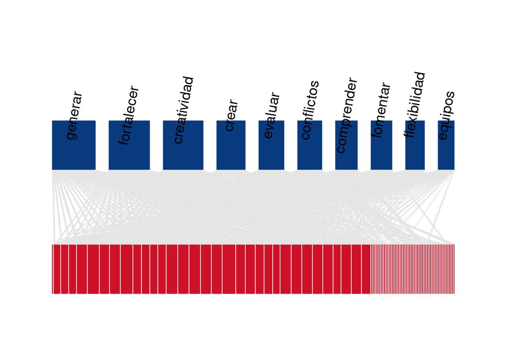

```r
library(bipartite)

plotweb(IM3, method = "normal",
        col.high = "#0A3A7E",
        bor.col.high = "#0A3A7E",
        col.low = "#CE1127",
        bor.col.low = "#CE1127",
        col.interaction = "grey90",
        bor.col.interaction = "grey90",
        low.lablength = 0,
        text.rot = 80,
        high.y = 1,
        ybig = 0.8,
        labsize = 2)
```